# Assignment3

### Team Members

- Quinn Turner // sqturner // 20576575 - Exploratory Data & Linear Regression & ANOVA
- Rebecca Rayner // rsrayner // 20562488 - Linear Regression & Two Means
- Yusuf Khaled // yhbkhale // 20508841 - Logistic Regression
- Samantha Villaluz // skvillal // 20582656 - Linear Regression & Two Means

### Assignment Breakdown

1. Exploratory Data Analysis
   - Normally Distributed Variables
   - Correlation using Levene’s Test
2. Hypothesis
   - Hypothesis #1: Low acidity and sugar content are major indicators of wine quality (Linear regression and ANOVA)
   - Hypothesis #2: Acidity is a strong predictor of wine colour (Logistic & linear regression)
   - Hypothesis #3: Red wine is of higher quality (Comparison of two means)

## Set up datasets

```r
redWineData <- read.csv("winequality-red.csv", header=T, sep = ";")
# Reduces 1599 observations to 1359 observations
redWineData <- redWineData[!duplicated(redWineData), ]
redWineData$color <- 1
redWineData$pHTransformed <- 10^redWineData$pH
redWineData$pH <- NULL
redWineData$quality <- factor(redWineData$quality, ordered = T)

head(redWineData)
```

```
##   fixed.acidity volatile.acidity citric.acid residual.sugar chlorides
## 1           7.4             0.70        0.00            1.9     0.076
## 2           7.8             0.88        0.00            2.6     0.098
## 3           7.8             0.76        0.04            2.3     0.092
## 4          11.2             0.28        0.56            1.9     0.075
## 6           7.4             0.66        0.00            1.8     0.075
## 7           7.9             0.60        0.06            1.6     0.069
##   free.sulfur.dioxide total.sulfur.dioxide density sulphates alcohol
## 1                  11                   34  0.9978      0.56     9.4
## 2                  25                   67  0.9968      0.68     9.8
## 3                  15                   54  0.9970      0.65     9.8
## 4                  17                   60  0.9980      0.58     9.8
## 6                  13                   40  0.9978      0.56     9.4
## 7                  15                   59  0.9964      0.46     9.4
##   quality color pHTransformed
## 1       5     1      3235.937
## 2       5     1      1584.893
## 3       5     1      1819.701
## 4       6     1      1445.440
## 6       5     1      3235.937
## 7       5     1      1995.262
```

```r
whiteWineData <- read.csv("winequality-white.csv", header=T, sep = ";")
# Reduces 4898 observations to 3961 observations
whiteWineData <- whiteWineData[!duplicated(whiteWineData), ]
whiteWineData$color <- 0
whiteWineData$pHTransformed <- 10^whiteWineData$pH
whiteWineData$pH <- NULL
whiteWineData$quality <- factor(whiteWineData$quality, ordered = T)

head(whiteWineData)
```

```
##    fixed.acidity volatile.acidity citric.acid residual.sugar chlorides
## 1            7.0             0.27        0.36           20.7     0.045
## 2            6.3             0.30        0.34            1.6     0.049
## 3            8.1             0.28        0.40            6.9     0.050
## 4            7.2             0.23        0.32            8.5     0.058
## 7            6.2             0.32        0.16            7.0     0.045
## 10           8.1             0.22        0.43            1.5     0.044
##    free.sulfur.dioxide total.sulfur.dioxide density sulphates alcohol
## 1                   45                  170  1.0010      0.45     8.8
## 2                   14                  132  0.9940      0.49     9.5
## 3                   30                   97  0.9951      0.44    10.1
## 4                   47                  186  0.9956      0.40     9.9
## 7                   30                  136  0.9949      0.47     9.6
## 10                  28                  129  0.9938      0.45    11.0
##    quality color pHTransformed
## 1        6     0      1000.000
## 2        6     0      1995.262
## 3        6     0      1819.701
## 4        6     0      1548.817
## 7        6     0      1513.561
## 10       6     0      1659.587
```

```r
wineData <- rbind(whiteWineData, redWineData)

str(wineData)
```

```
## 'data.frame':    5320 obs. of  13 variables:
##  $ fixed.acidity       : num  7 6.3 8.1 7.2 6.2 8.1 8.1 8.6 7.9 6.6 ...
##  $ volatile.acidity    : num  0.27 0.3 0.28 0.23 0.32 0.22 0.27 0.23 0.18 0.16 ...
##  $ citric.acid         : num  0.36 0.34 0.4 0.32 0.16 0.43 0.41 0.4 0.37 0.4 ...
##  $ residual.sugar      : num  20.7 1.6 6.9 8.5 7 1.5 1.45 4.2 1.2 1.5 ...
##  $ chlorides           : num  0.045 0.049 0.05 0.058 0.045 0.044 0.033 0.035 0.04 0.044 ...
##  $ free.sulfur.dioxide : num  45 14 30 47 30 28 11 17 16 48 ...
##  $ total.sulfur.dioxide: num  170 132 97 186 136 129 63 109 75 143 ...
##  $ density             : num  1.001 0.994 0.995 0.996 0.995 ...
##  $ sulphates           : num  0.45 0.49 0.44 0.4 0.47 0.45 0.56 0.53 0.63 0.52 ...
##  $ alcohol             : num  8.8 9.5 10.1 9.9 9.6 11 12 9.7 10.8 12.4 ...
##  $ quality             : Ord.factor w/ 7 levels "3"<"4"<"5"<"6"<..: 4 4 4 4 4 4 3 3 3 5 ...
##  $ color               : num  0 0 0 0 0 0 0 0 0 0 ...
##  $ pHTransformed       : num  1000 1995 1820 1549 1514 ...
```

## Exploratory Data Analysis

We begin by determining the underlying distribution for each variable within the wine dataset. This will allow us to determine which tests and analyses we can perform on what variables, as well as getting a feel for the data.

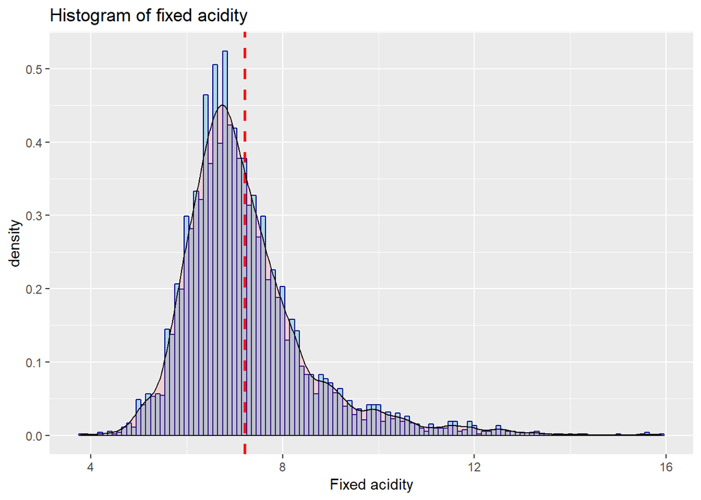

```r
# Per-variable histogram
ggplot(wineData, aes(fixed.acidity)) + geom_histogram(aes(y=..density..), binwidth = .1, color="darkblue", fill="lightblue") + labs(title = 'Histogram of fixed acidity', x = 'Fixed acidity') + geom_vline(aes(xintercept=mean(fixed.acidity)), color="red", linetype="dashed", size=1) + geom_density(alpha=.2, fill="#FF6666")
```

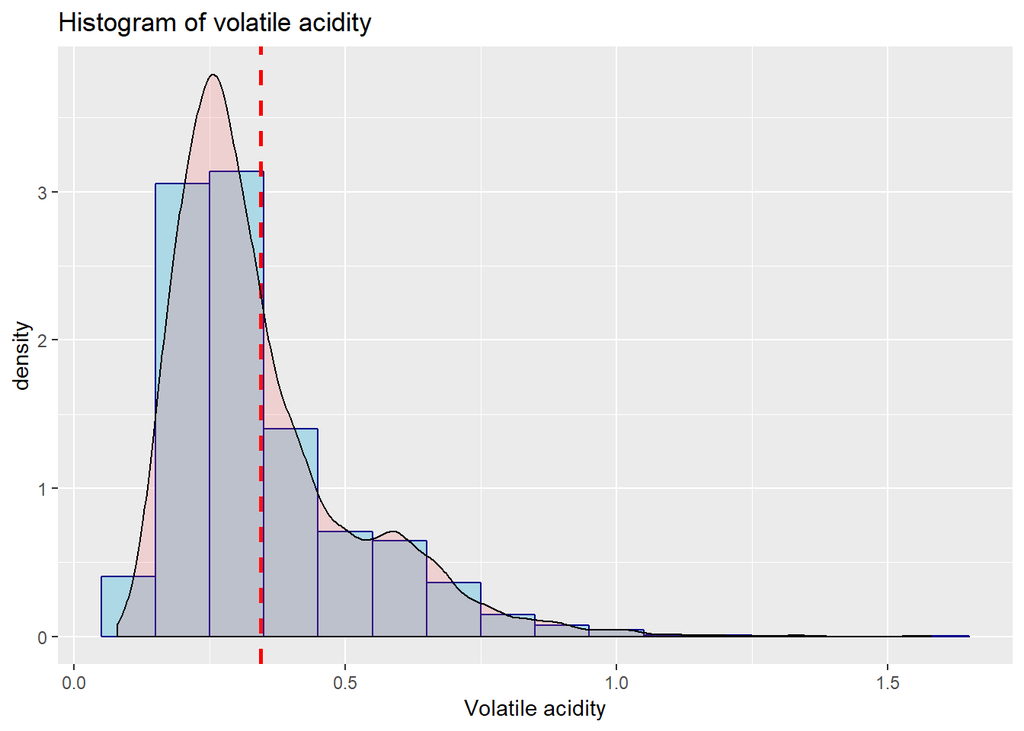

```r
ggplot(wineData, aes(volatile.acidity)) + geom_histogram(aes(y=..density..), binwidth = .1, color="darkblue", fill="lightblue") + labs(title = 'Histogram of volatile acidity', x = 'Volatile acidity') + geom_vline(aes(xintercept=mean(volatile.acidity)), color="red", linetype="dashed", size=1) + geom_density(alpha=.2, fill="#FF6666")
```

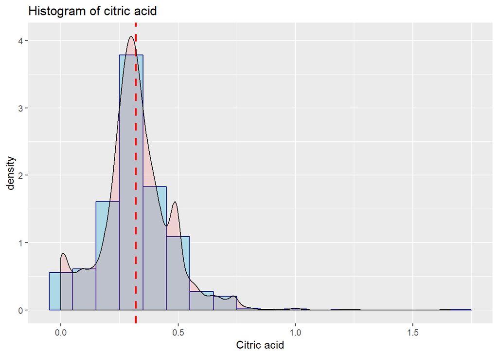

```r
ggplot(wineData, aes(citric.acid)) + geom_histogram(aes(y=..density..), binwidth = .1, color="darkblue", fill="lightblue") + labs(title = 'Histogram of citric acid', x = 'Citric acid') + geom_vline(aes(xintercept=mean(citric.acid)), color="red", linetype="dashed", size=1) + geom_density(alpha=.2, fill="#FF6666")
```

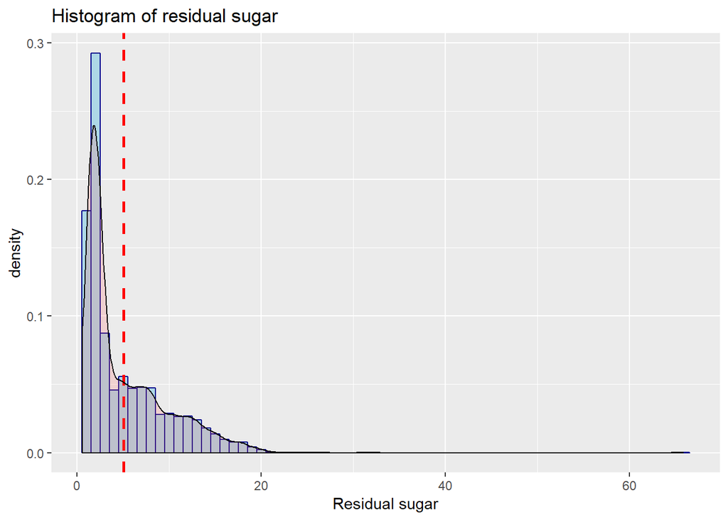

```r
ggplot(wineData, aes(residual.sugar)) + geom_histogram(aes(y=..density..), binwidth = 1, color="darkblue", fill="lightblue") + labs(title = 'Histogram of residual sugar', x = 'Residual sugar') + geom_vline(aes(xintercept=mean(residual.sugar)), color="red", linetype="dashed", size=1) + geom_density(alpha=.2, fill="#FF6666")
```

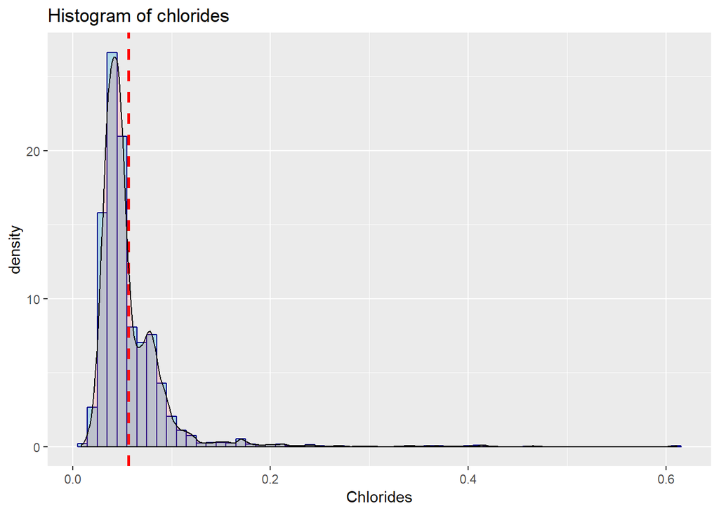

```r
ggplot(wineData, aes(chlorides)) + geom_histogram(aes(y=..density..), binwidth = .01, color="darkblue", fill="lightblue") + labs(title = 'Histogram of chlorides', x = 'Chlorides') + geom_vline(aes(xintercept=mean(chlorides)), color="red", linetype="dashed", size=1) + geom_density(alpha=.2, fill="#FF6666")
```

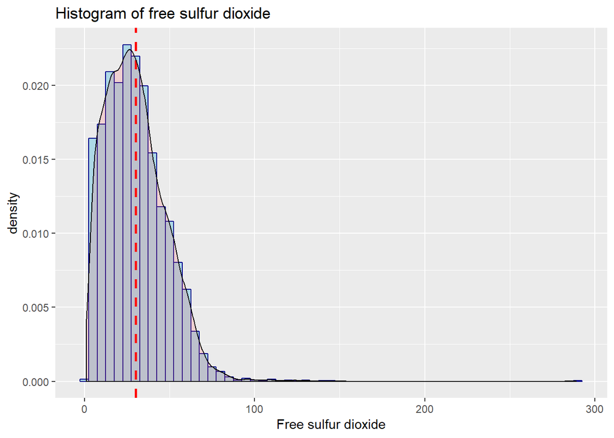

```r
ggplot(wineData, aes(free.sulfur.dioxide)) + geom_histogram(aes(y=..density..), binwidth = 5, color="darkblue", fill="lightblue") + labs(title = 'Histogram of free sulfur dioxide', x = 'Free sulfur dioxide') + geom_vline(aes(xintercept=mean(free.sulfur.dioxide)), color="red", linetype="dashed", size=1) + geom_density(alpha=.2, fill="#FF6666")
```

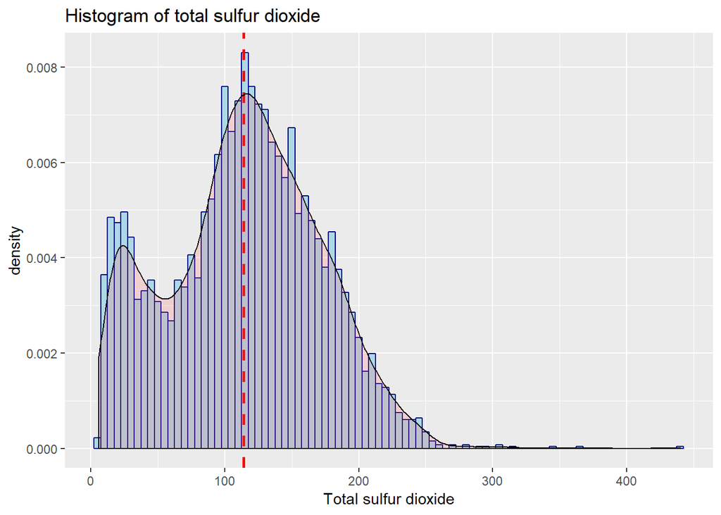

```r
ggplot(wineData, aes(total.sulfur.dioxide)) + geom_histogram(aes(y=..density..), binwidth = 5, color="darkblue", fill="lightblue") + labs(title = 'Histogram of total sulfur dioxide', x = 'Total sulfur dioxide') + geom_vline(aes(xintercept=mean(total.sulfur.dioxide)), color="red", linetype="dashed", size=1) + geom_density(alpha=.2, fill="#FF6666")
```

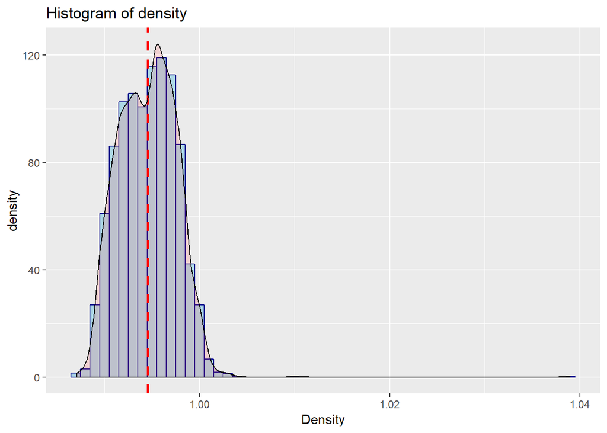

```r
ggplot(wineData, aes(density)) + geom_histogram(aes(y=..density..), binwidth = .001, color="darkblue", fill="lightblue") + labs(title = 'Histogram of density', x = 'Density') + geom_vline(aes(xintercept=mean(density)), color="red", linetype="dashed", size=1) + geom_density(alpha=.2, fill="#FF6666")
```

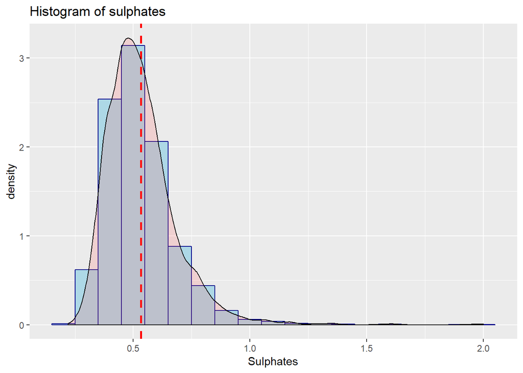

```r
ggplot(wineData, aes(sulphates)) + geom_histogram(aes(y=..density..), binwidth = .1, color="darkblue", fill="lightblue") + labs(title = 'Histogram of sulphates', x = 'Sulphates') + geom_vline(aes(xintercept=mean(sulphates)), color="red", linetype="dashed", size=1) + geom_density(alpha=.2, fill="#FF6666")
```

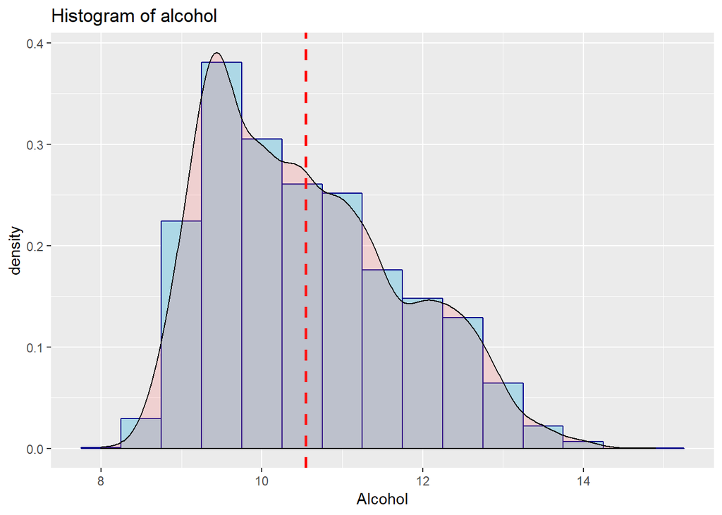

```r
ggplot(wineData, aes(alcohol)) + geom_histogram(aes(y=..density..), binwidth = .5, color="darkblue", fill="lightblue") + labs(title = 'Histogram of alcohol', x = 'Alcohol') + geom_vline(aes(xintercept=mean(alcohol)), color="red", linetype="dashed", size=1) + geom_density(alpha=.2, fill="#FF6666")
```

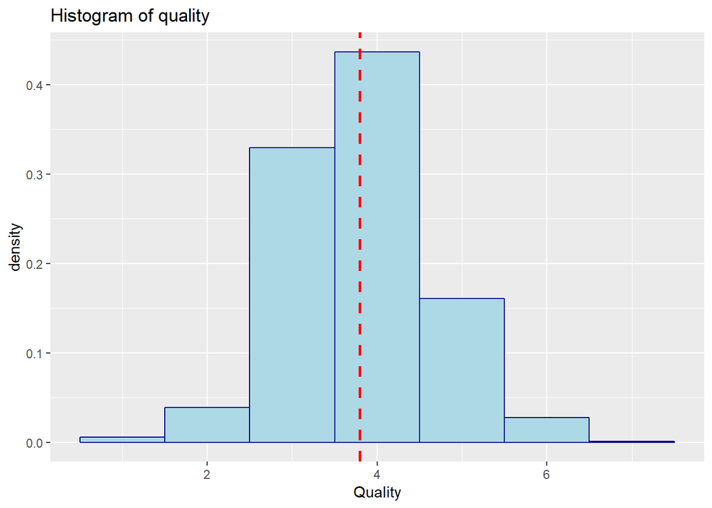

```r
ggplot(wineData, aes(as.numeric(quality))) + geom_histogram(aes(y=..density..), binwidth = 1, color="darkblue", fill="lightblue") + labs(title = 'Histogram of quality', x = 'Quality') + geom_vline(aes(xintercept=mean(as.numeric(quality))), color="red", linetype="dashed", size=1)
```

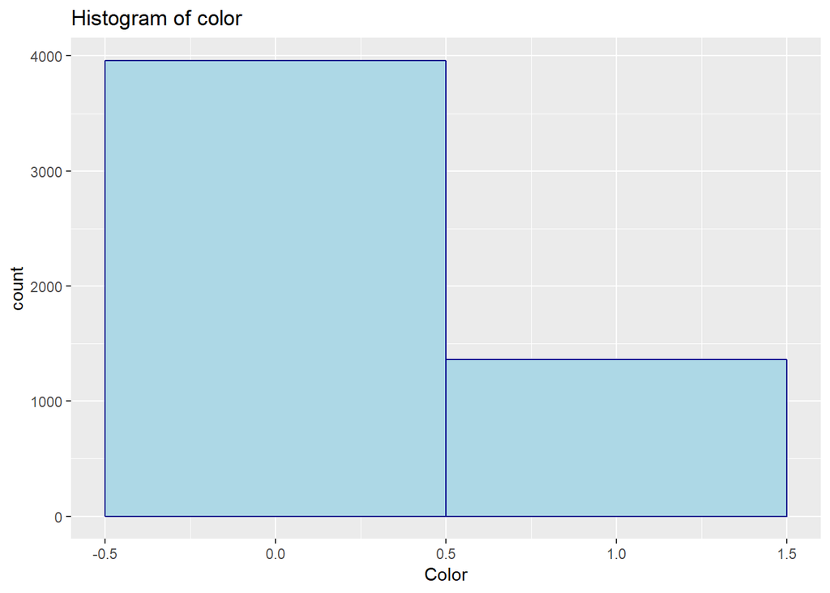

```r
ggplot(wineData, aes(color)) + geom_histogram(binwidth = 1, color="darkblue", fill="lightblue") + labs(title = 'Histogram of color', x = 'Color')
```

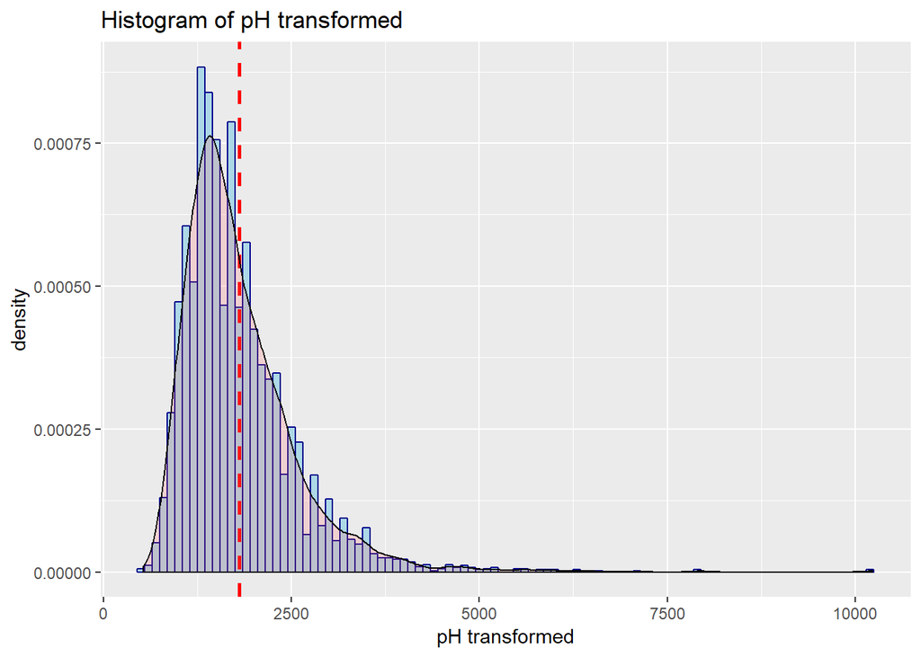

```r
ggplot(wineData, aes(pHTransformed)) + geom_histogram(aes(y=..density..), binwidth = 100, color="darkblue", fill="lightblue") + labs(title = 'Histogram of pH transformed', x = 'pH transformed') + geom_vline(aes(xintercept=mean(pHTransformed)), color="red", linetype="dashed", size=1) + geom_density(alpha=.2, fill="#FF6666")
```

We now have have an glimpse of understanding for the distribution of each variable for wine. These histograms include both red and white wine in one plot. Most variables are positively skewed.

For a closer look at normality, we can show QQ plots. To reduce variance, we can view just white wine alone.

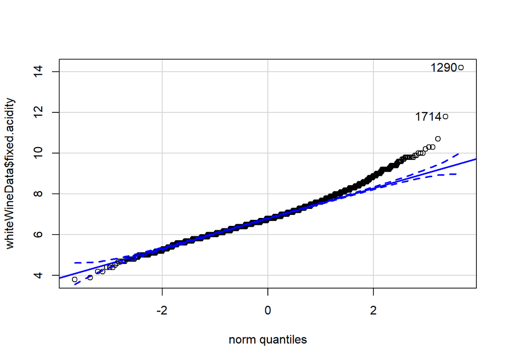

```
## [1] 1290 1714
```

```r
qqPlot(whiteWineData$fixed.acidity)
```

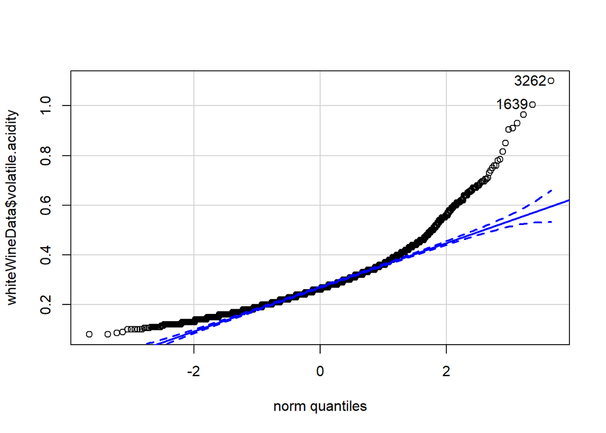

```
## [1] 3262 1639
```

```r
qqPlot(whiteWineData$volatile.acidity)
```

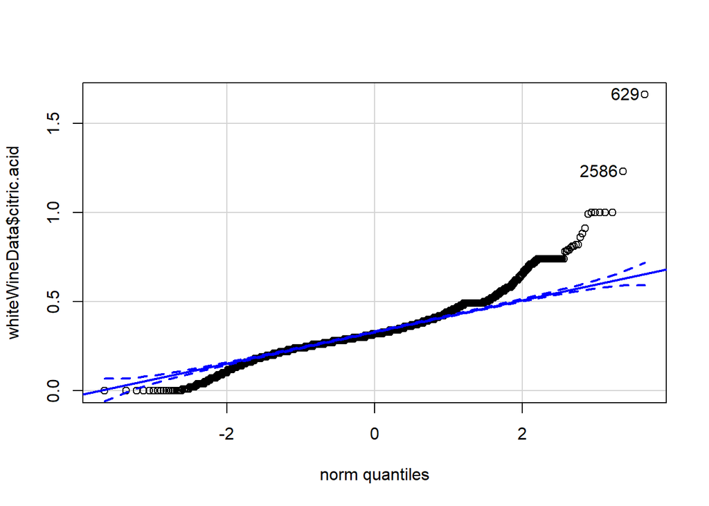

```
## [1]  629 2586
```

```r
qqPlot(whiteWineData$citric.acid)
```

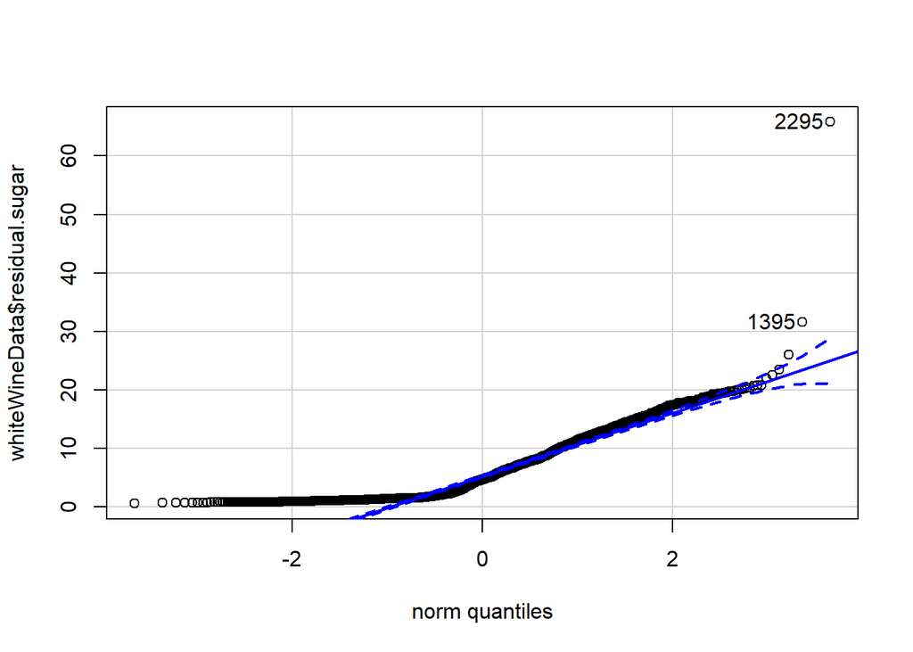

```
## [1] 2295 1395
```

```r
qqPlot(whiteWineData$residual.sugar)
```